# CompMus Portfolio

Lex Johan

2/14/2021

## R Markdown

For my corpus, I chose four pianists that took on the monumental task of playing all 32 of Beethoven’s sonatas: Arthur Schnabel, Claudio Arrau, Paul Lewis, and Richard Goode. Beethoven’s sonata legacy is certainly intimidating but has left all the pianists that came after him with more than enough room for their own interpretations of his work.

Spotify’s audio features are mainly geared towards more modern songs, with features like danceability and speechiness. However, I believe that the individual pianist’s fingerprints can still shine through in features like energy and tempo between the pieces.

These features are especially interesting to me in Beethoven’s sonatas from the “late” period, which are notoriously difficult to play. These sonatas are: No. 28, No. 29, No. 30, No. 31, and No. 32. I believe that you truly have to make these sonatas your “own” in some way in order to master them, figuring out how these pianists do this from a computational musicology perspective is my ultimate goal for this portfolio.

Lastly, Arthur Schnabel and Claudio Arrau have both recorded their renditions in the thirties, while Richard Goode and Paul Lewis have recorded theirs in the 90s and 10s respectively. It will be interesting to see whether these two distinctive time periods have left their mark on the music.

https://open.spotify.com/album/0TC4ndTblPOpZ5sbYKLouD

https://open.spotify.com/album/4YdnrlJo8YshOPIFnFnIxL

https://open.spotify.com/album/74bLPtOSrC7zSir6INgq5S?si=wEevmTKOSF2Fd5s4FBprmA

https://open.spotify.com/album/4bNwPPpk01D8pVV9IFSBde?si=B_yuvyZZTd6UFJs9udX90Q

These are just some exploratory plots:

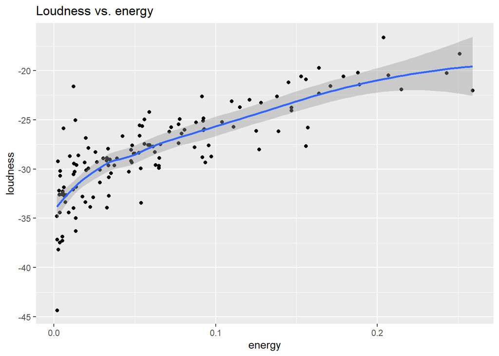

```r
music <- get_playlist_audio_features("","63kg8llpGnSc62Gxl98GRp")

mut <- mutate(music, mode = ifelse(mode == 0, "minor", "major"))

ggplot(music, aes(energy, loudness)) +geom_point() + geom_smooth() + ggtitle("Loudness vs. energy")
```

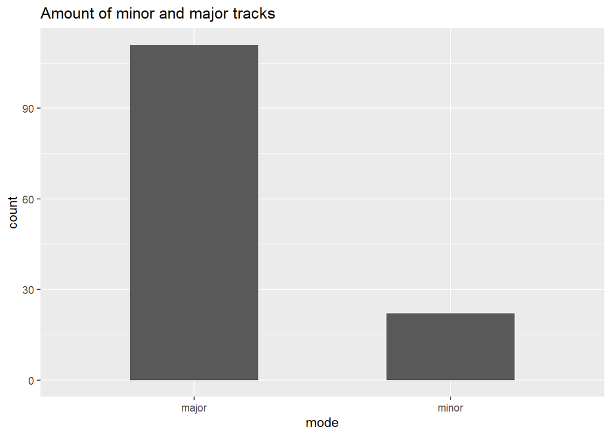

```r
ggplot(mut, aes(mode)) +geom_bar( width=0.5) + ggtitle("Amount of minor and major tracks")
```